# Statistics Exam 2017

712538

04 August 2017

### Loading packages…

```r
library(plyr)
library(tidyr)
library(dplyr)
```

# Question 1

1. The data set is untidy in that two variables are stored together in a single column (group and location), and will need to be spread into two distinct columns. The data is also untidy in that pain intensity is a measure between 0 and 10 - here there are many pain intensity values of 9999, which cannot be included in the data analysis.

```r
#Loading the data csv...
pain <- read.csv("https://dl.dropboxusercontent.com/u/11805474/painblogr/biostats/exam-data-2017/question_1.csv")

#quick look:
head(pain)
```

```
##   Patient.ID Group.and.location    Sex       Baseline         Week.4
## 1       <NA>              NA_NA   <NA> Pain intensity Pain intensity
## 2         J1     P_Johannesburg Female              8           9999
## 3         J3     T_Johannesburg Female              9           9999
## 4         J4     P_Johannesburg Female              5              3
## 5         J5     P_Johannesburg Female              7           9999
## 6         J6     P_Johannesburg Female              7           9999
##           Week.8
## 1 Pain intenisty
## 2           9999
## 3           9999
## 4              0
## 5           9999
## 6           9999
```

```r
summary(pain)
```

```
##    Patient.ID       Group.and.location     Sex        Baseline
##  J1     :  1   P_Manguzi     :28       Female:97   10     :37
##  J10    :  1   P_Zithulele   :26       Male  :63   7      :25
##  J11    :  1   P_Johannesburg:24       NA's  : 1   8      :21
##  J12    :  1   T_Johannesburg:23                   5      :17
##  J17    :  1   T_Zithulele   :23                   9999   :16
##  (Other):155   T_Manguzi     :19                   9      :15
##  NA's   :  1   (Other)       :18                   (Other):30
##      Week.4       Week.8
##  9999   :57   9999   :59
##  0      :28   0      :32
##  7      :17   8      :20
##  9      :15   10     :13
##  8      :12   7      :10
##  10     :10   5      : 8
##  (Other):22   (Other):19
```

```r
#removing pain intensity values outside of the scale
painsub1 <- subset(pain, Baseline!="9999", select=Patient.ID:Week.8)
painsub2 <- subset(painsub1, Week.4!="9999", select=Patient.ID:Week.8)
painsub3 <- subset(painsub2, Week.8!="9999", select=Patient.ID:Week.8)
head(painsub3)
```

```
##    Patient.ID Group.and.location    Sex       Baseline         Week.4
## 1        <NA>              NA_NA   <NA> Pain intensity Pain intensity
## 4          J4     P_Johannesburg Female              5              3
## 8          J9     T_Johannesburg Female             10              8
## 9         J10     T_Johannesburg   Male             10              9
## 10        J11     P_Johannesburg Female              9              8
## 14        J19     T_Johannesburg Female              9              8
##            Week.8
## 1  Pain intenisty
## 4               0
## 8               8
## 9               9
## 10             10
## 14              9
```

```r
#separating group and location
pain_clean <- separate(painsub3, Group.and.location, into = c("Group", "Location"))
head(pain_clean)
```

```
##    Patient.ID Group     Location    Sex       Baseline         Week.4
## 1        <NA>    NA           NA   <NA> Pain intensity Pain intensity
## 4          J4     P Johannesburg Female              5              3
## 8          J9     T Johannesburg Female             10              8
## 9         J10     T Johannesburg   Male             10              9
## 10        J11     P Johannesburg Female              9              8
## 14        J19     T Johannesburg Female              9              8
##            Week.8
## 1  Pain intenisty
## 4               0
## 8               8
## 9               9
## 10             10
## 14              9
```

### Data Plot

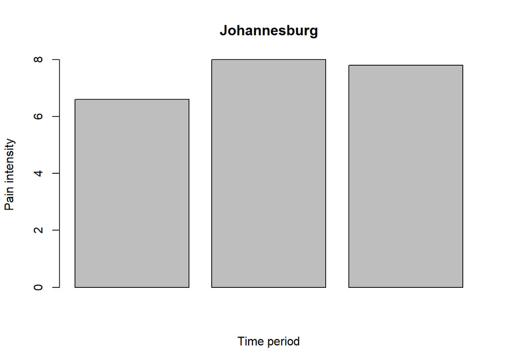

```r
#Subsetting Johannesburg
painJ <- subset(pain_clean, Location=="Johannesburg", select=Location:Week.8)
#changing factors to numerics
baseJ <- as.numeric(painJ$Baseline)
W4J <- as.numeric(painJ$Week.4)
W8J <- as.numeric(painJ$Week.8)
#calculating respective means
meansJ <- c(mean(baseJ), mean(W4J), mean(W8J))
#barplot for JOhannesburg
barplot(meansJ, main="Johannesburg", ylab="Pain intensity", xlab="Time period")
```

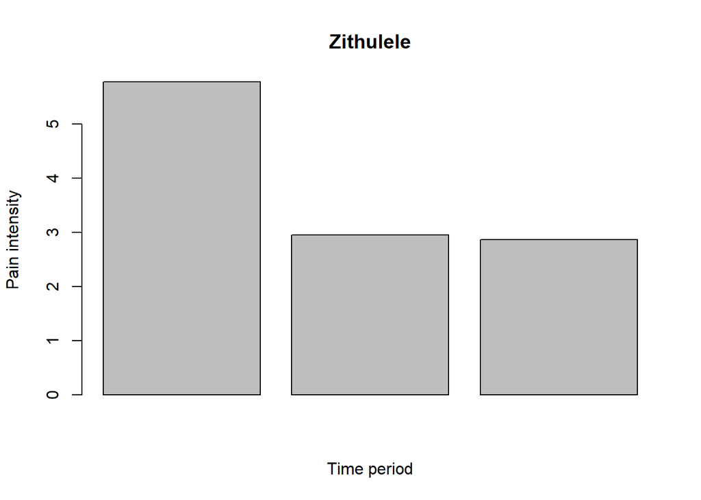

```r
#Subsetting Zithulele
painZ <- subset(pain_clean, Location=="Zithulele", select=Location:Week.8)
#changing factors to numerics
baseZ <- as.numeric(painZ$Baseline)
W4Z <- as.numeric(painZ$Week.4)
W8Z <- as.numeric(painZ$Week.8)
#calculatin respective means
meansZ <- c(mean(baseZ), mean(W4Z), mean(W8Z))
#barplot for Zithulele
barplot(meansZ, main="Zithulele", ylab="Pain intensity", xlab="Time period")
```

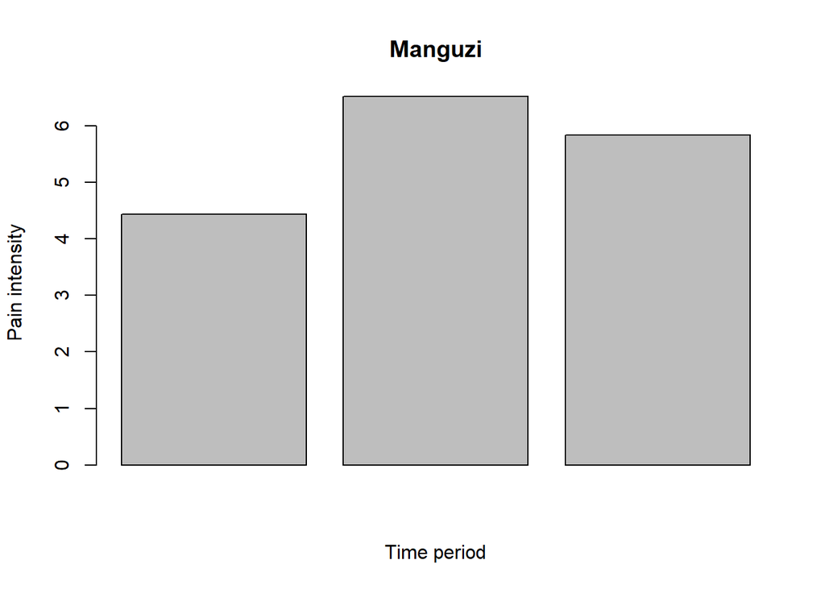

```r
#Subsetting Manguzi
painM <- subset(pain_clean, Location=="Manguzi", select=Location:Week.8)
#changing factors to numerics
baseM <- as.numeric(painM$Baseline)
W4M <- as.numeric(painM$Week.4)
W8M <- as.numeric(painM$Week.8)
#calculatin respective means
meansM <- c(mean(baseM), mean(W4M), mean(W8M))
#barplot for Manguzi
barplot(meansM, main="Manguzi", ylab="Pain intensity", xlab="Time period")
```

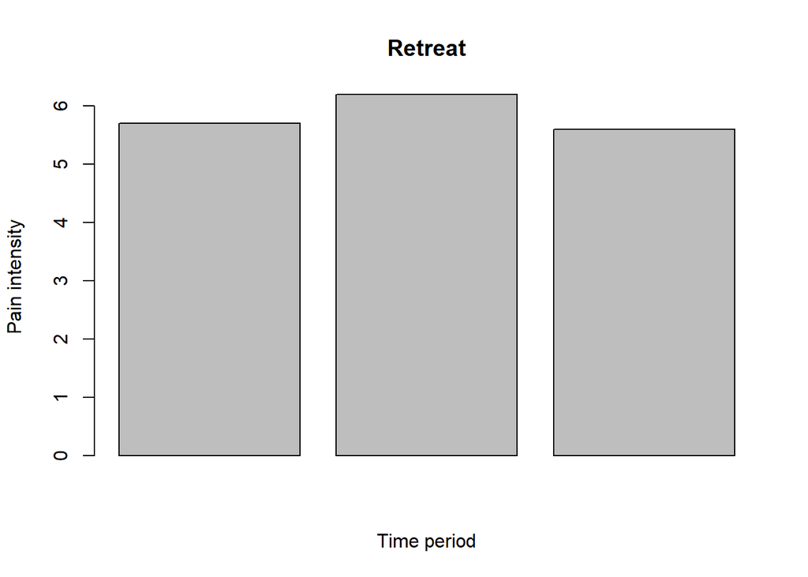

```r
#Subsetting Retreat
painR <- subset(pain_clean, Location=="Retreat", select=Location:Week.8)
#changing factors to numerics
baseR <- as.numeric(painR$Baseline)
W4R <- as.numeric(painR$Week.4)
W8R <- as.numeric(painR$Week.8)
#calculatin respective means
meansR <- c(mean(baseR), mean(W4R), mean(W8R))
#barplot for Retreat
barplot(meansR, main="Retreat", ylab="Pain intensity", xlab="Time period")
```

# Question 2

```r
#loading data csv...
fertile <- read.csv("https://dl.dropboxusercontent.com/u/11805474/painblogr/biostats/exam-data-2017/question_2.csv")

#quick look
head(fertile)
```

```
##          State Fertility Catholic
## 1   Courtelary      80.2     9.96
## 2     Delemont      83.1    84.84
## 3 Franches-Mnt      92.5    93.40
## 4      Moutier      85.8    33.77
## 5   Neuveville      76.9     5.16
## 6   Porrentruy      76.1    90.57
```

```r
summary(fertile)
```

```
##       State      Fertility        Catholic
##  Aigle   : 1   Min.   :35.00   Min.   :  2.150
##  Aubonne : 1   1st Qu.:64.70   1st Qu.:  5.195
##  Avenches: 1   Median :70.40   Median : 15.140
##  Boudry  : 1   Mean   :70.14   Mean   : 41.144
##  Broye   : 1   3rd Qu.:78.45   3rd Qu.: 93.125
##  Conthey : 1   Max.   :92.50   Max.   :100.000
##  (Other) :41
```

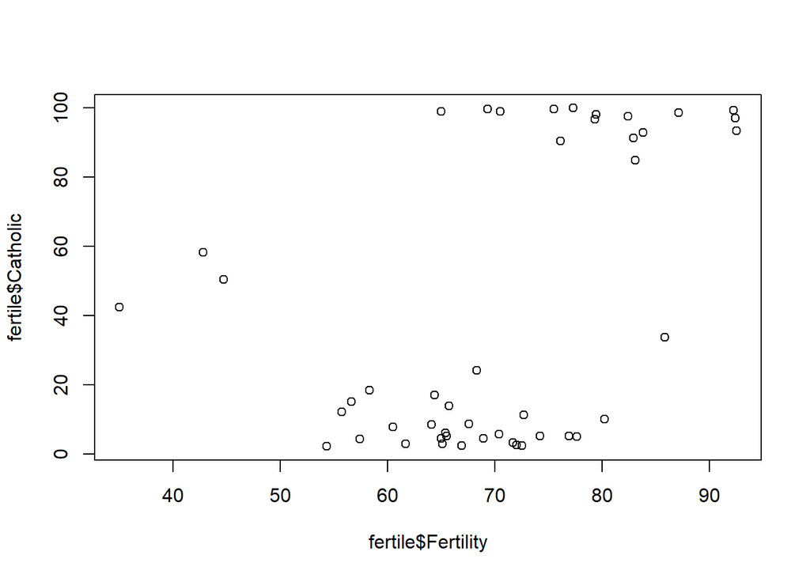

```r
#exploratory plots
plot(fertile$Fertility, fertile$Catholic)
```

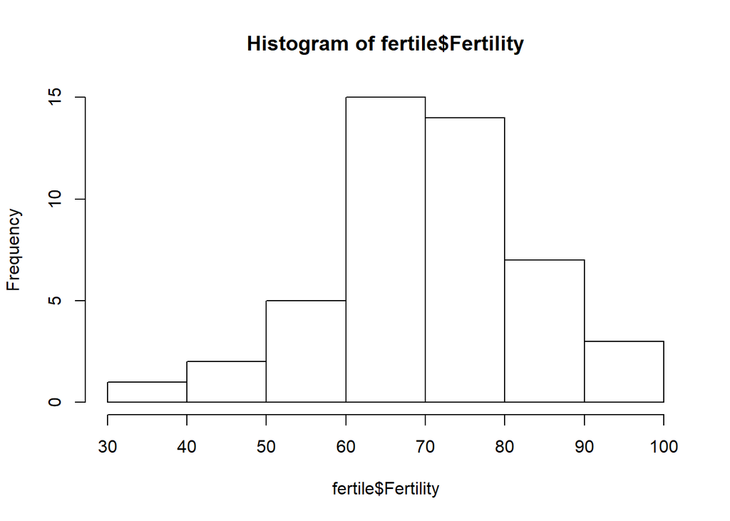

```r
hist(fertile$Fertility)
```

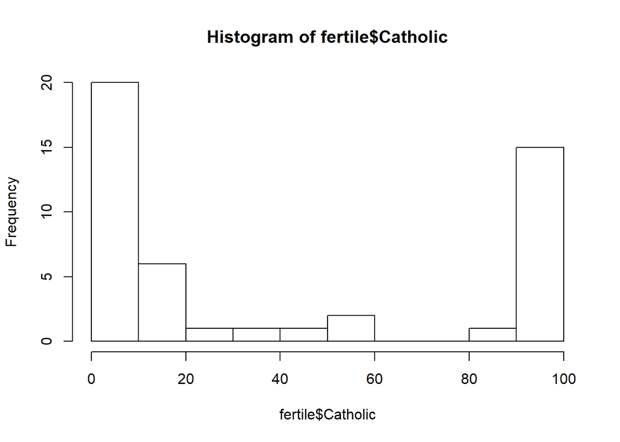

```r
hist(fertile$Catholic)
```

## Description of data and test:

### Fertility and percentage Catholicism are both continuous numerical variables. State is a nominal variable but is irrelevant to the question posed (relationship between religion and fertility). Therefore, a correlation test will be used to establish whether there is a relationship between the percentage of Catholicism and the level of fertility.The histograms show that both variables cannot be considered parametric and so a Spearman’s correlation will be used. The assumptions underlying a Spearman’s correlation test are linearity, absence of outliers, independence of observations, related pairs and homoskedasticity.

### Null hypothesis: There is no correlation between the percentage of catholicism and the level of fertility

### Alternative hypothesis: There is a correlation between the percentage of catholicism and the level of fertility

```r
#Spearman's test on Fertility vs percentage Catholicism
cor.test(x=fertile$Fertility, y=fertile$Catholic, method="spearman")
```

```
##
##  Spearman's rank correlation rho
##
## data:  fertile$Fertility and fertile$Catholic
## S = 10142, p-value = 0.003851
## alternative hypothesis: true rho is not equal to 0
## sample estimates:
##       rho
## 0.4136456
```

# Question 3

```r
#loading data csv...
crop <- read.csv("https://dl.dropboxusercontent.com/u/11805474/painblogr/biostats/exam-data-2017/question_3.csv")

#quick look
head(crop)
```

```
##   control treatment_1 treatment_2
## 1    4.17        4.81        6.31
## 2    5.58        4.17        5.12
## 3    5.18        4.41        5.54
## 4    6.11        3.59        5.50
## 5    4.50        5.87        5.37
## 6    4.61        3.83        5.29
```

```r
summary(crop)
```

```
##     control       treatment_1     treatment_2
##  Min.   :4.170   Min.   :3.590   Min.   :4.920
##  1st Qu.:4.550   1st Qu.:4.207   1st Qu.:5.268
##  Median :5.155   Median :4.550   Median :5.435
##  Mean   :5.032   Mean   :4.661   Mean   :5.526
##  3rd Qu.:5.293   3rd Qu.:4.870   3rd Qu.:5.735
##  Max.   :6.110   Max.   :6.030   Max.   :6.310
```

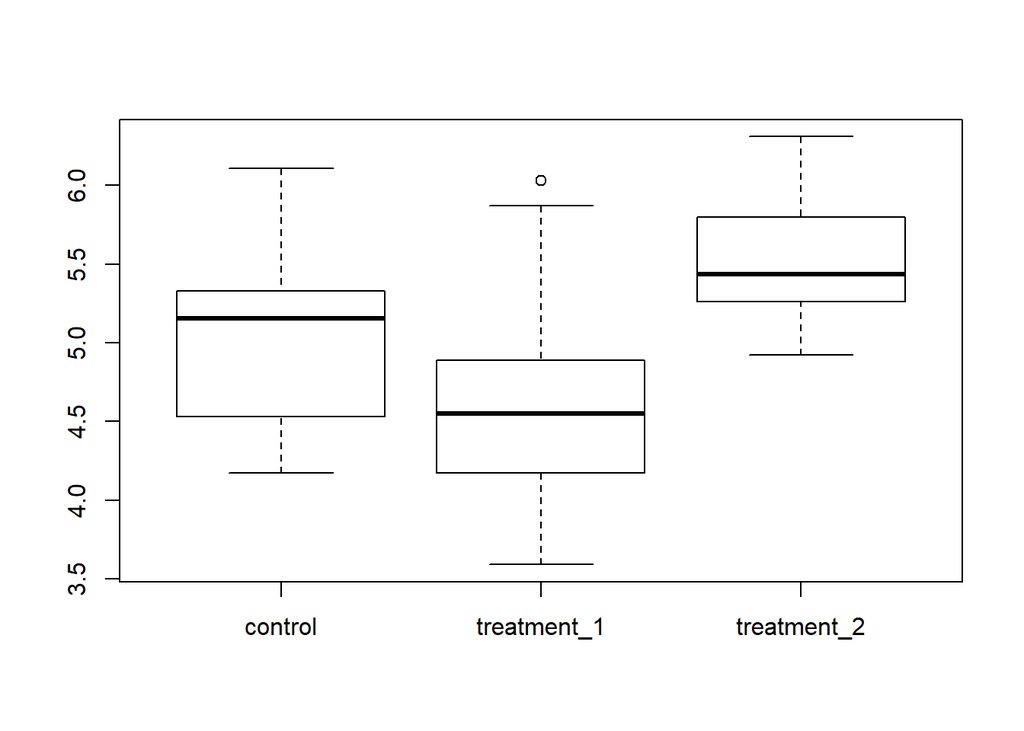

```r
#exploratory plots
boxplot(crop)
```

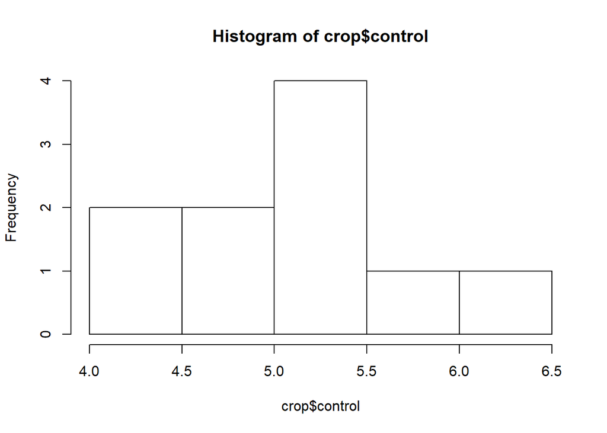

```r
hist(crop$control)
```

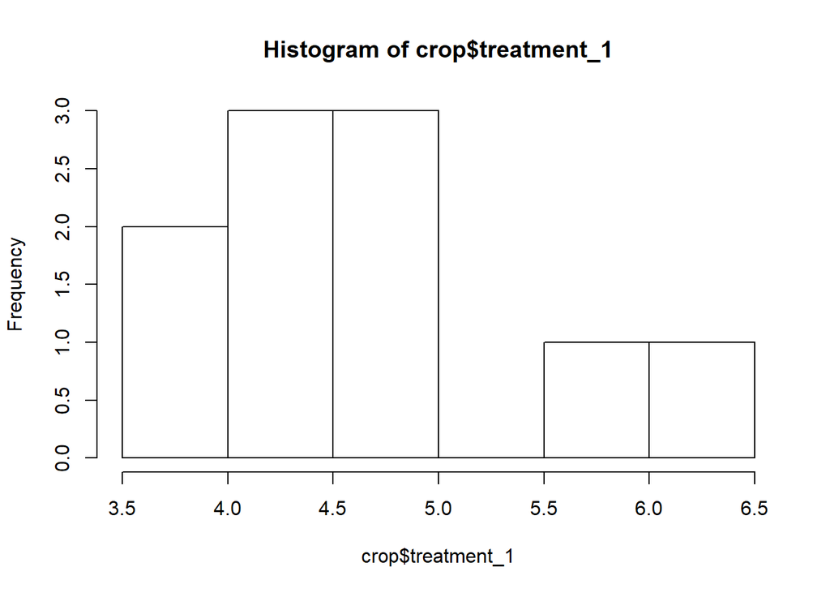

```r
hist(crop$treatment_1)
```

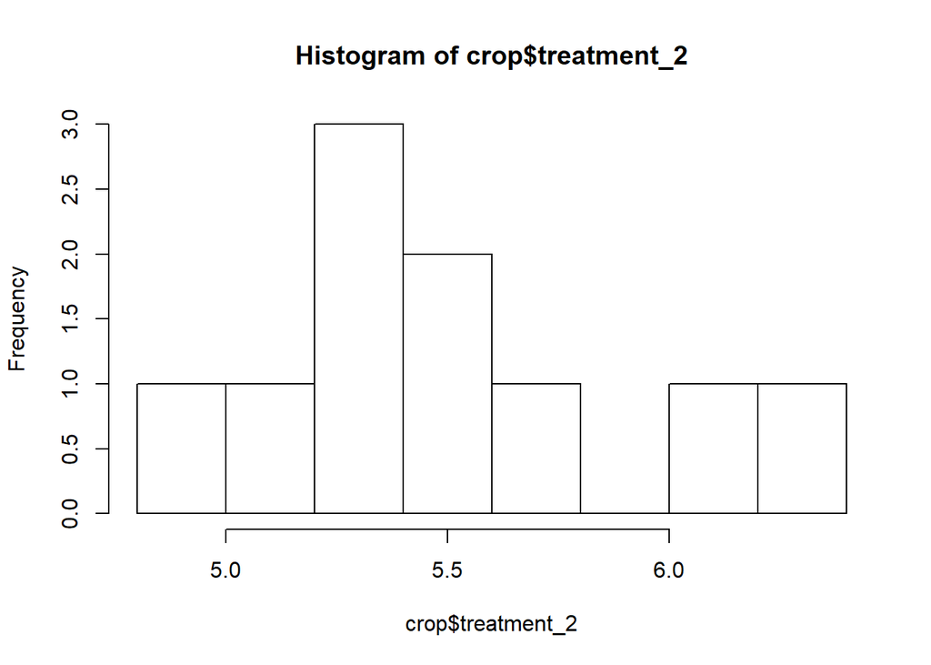

```r
hist(crop$treatment_2)
```

```r
#tidying from wide to long format
crop1 <- gather(crop, Treatment, Yield)
head(crop1)
```

```
##   Treatment Yield
## 1   control  4.17
## 2   control  5.58
## 3   control  5.18
## 4   control  6.11
## 5   control  4.50
## 6   control  4.61
```

```r
summary(crop1)
```

```
##   Treatment             Yield
##  Length:30          Min.   :3.590
##  Class :character   1st Qu.:4.550
##  Mode  :character   Median :5.155
##                     Mean   :5.073
##                     3rd Qu.:5.530
##                     Max.   :6.310
```

## Description of data and test:

### Variables are all continuous, but do not all display convincing normality in the plotted histograms. As three non-parametric groups are to be compared and the data is unpaired, a Kruskal-Wallis test will be used to check for differences in crop yield between the three groups. The assumptions underlying the Kruskal-Wallis test are that errors are independent, data is unmatched and that the samples are derived from populations with similar distributions.

### Null hypothesis: There is no difference between crop yield according to treatment

### Alternative hypothesis: There is a difference between crop yield according to treatment

```r
#Kruskal-Wallis test for difference
kruskal.test(Yield ~ as.factor(Treatment), data = crop1)
```

```
##
##  Kruskal-Wallis rank sum test
##
## data:  Yield by as.factor(Treatment)
## Kruskal-Wallis chi-squared = 7.9882, df = 2, p-value = 0.01842
```

### The kruskal-wallis test produces a p-value of 0.01842 with 2 degrees of freedom. The p-value is below 0.05 and thus significant, hence the null hypothesis can be rejected - there is a statistical difference between crop yields according to treatment. According to the initial boxplot, treatment 2 appears to produce the highest yield. A post-hoc analysis using the pairwise Wilcoxon test will be performed

```r
#post-hoc pairwise wilcoxon test with holm adjustment for mutliple comparisons
pairwise.wilcox.test(x = crop1$Yield, g = crop1$Treatment,  p.adjust.methods="holm", paired=FALSE)
```

```
##
##  Pairwise comparisons using Wilcoxon rank sum test
##
## data:  crop1$Yield and crop1$Treatment
##
##             control treatment_1
## treatment_1 0.199   -
## treatment_2 0.126   0.027
##
## P value adjustment method: holm
```

### The pairwise Wilcoxon test gave the following p-values: 0.199 for treatment 1 vs control, 0.126 for treatment 2 vs control and 0.027 for treatment 1 vs treatment 2. The only significant difference is that between treatment 1 and treatment 2. Thus it can be concluded that while neither treatment produces a significantly different yield to that obtained in the control condition, treatment 2 produces a significantly higher yield than that obtained in treatment 1.

# Question 4

```r
#loading data csv...
heart <- read.csv("https://dl.dropboxusercontent.com/u/11805474/painblogr/biostats/exam-data-2017/question_4.csv")

#quick look
head(heart)
```

```
##   Diet     Condition
## 1  AHA Heart_disease
## 2  AHA Heart_disease
## 3  AHA Heart_disease
## 4  AHA Heart_disease
## 5  AHA Heart_disease
## 6  AHA Heart_disease
```

```r
summary(heart)
```

```
##             Diet             Condition
##  AHA          :303   Cancer       : 22
##  Mediterranean:302   Healthy      :512
##                      Heart_disease: 71
```

```r
#exploratory plots
heart_tbl <- table(heart$Diet, heart$Condition)
heart_tbl
```

```
##
##                 Cancer Healthy Heart_disease
##   AHA               15     239            49
##   Mediterranean      7     273            22
```

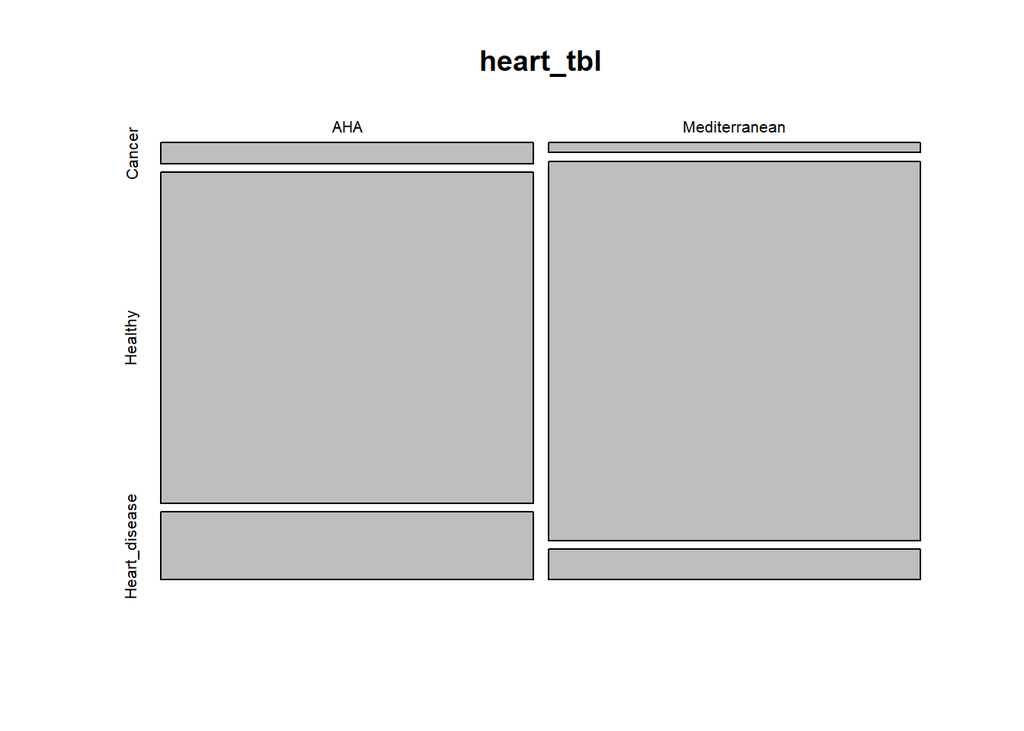

```r
plot(heart_tbl)
```

## Description of data and test:

### Data is categorical and thus, organised into a contingency table, can be analysed by a chi-squared test. The assumptions underlying a chi-squared test are that the sampling is random, observations are independent, the sample is sufficiently large, and that the contingency table of the data follows a chi-squared distribution.

### Null hypothesis: There is no difference in disease outcome according to diet

### Alternative hypothesis: There is a difference in disease outcome according to diet

```r
#Analysis of entire table using a chi-squared test
chisq.test(heart_tbl)
```

```
##
##  Pearson's Chi-squared test
##
## data:  heart_tbl
## X-squared = 15.433, df = 2, p-value = 0.0004454
```

### The chi-squared test gives a p-value of 0.0004454 with 2 degrees of freedom. This p-value is below 0.05 and thus the null hypothesis can be rejected. It can be concluded that there is a difference in disease outcome according to diet. The table will be divided into 2x2 tables to be reanalysed in order to find where the difference is.

```r
#Subsetting tables
ch <- heart_tbl[, 1:2]
ch
```

```
##
##                 Cancer Healthy
##   AHA               15     239
##   Mediterranean      7     273
```

```r
hhd <- heart_tbl[, 2:3]
hhd
```

```
##
##                 Healthy Heart_disease
##   AHA               239            49
##   Mediterranean     273            22
```

```r
#chi-squared test for cancer vs healthy
chisq.test(ch)
```

```
##
##  Pearson's Chi-squared test with Yates' continuity correction
##
## data:  ch
## X-squared = 3.0956, df = 1, p-value = 0.0785
```

```r
#chi-squared test for healthy vs heart disease
chisq.test(hhd)
```

```
##
##  Pearson's Chi-squared test with Yates' continuity correction
##
## data:  hhd
## X-squared = 11.566, df = 1, p-value = 0.0006718
```

### The p-value obtained for the outcomes of cancer vs healthy was 0.0785 (1 degree of freedom), thus it is concluded that diet does not influence the outcome of cancer vs being healthy. However, the p-value for obtained for the outcomes of heart disease vs healthy was 0.0006718 (1 degree of freedom), thus it is concluded that diet does affect the outcome of heart disease vs being healthy. The Mediterranean diet can be concluded to be superior in preventing heart disease, but not in preventing cancer.